# 4 Solving for zeros with julia

A notebook for this material: ipynb

## 4.1 Introduction

A *zero* of the function $f$ is a value $x$ with $f(x) = 0$.

Solving for zero of a function is a mathematical skill taught early on. In some cases, such as with linear equations, solving for zeros can be done directly using algebra. Similarly, in the case of factorable polynomials, we are taught to factor and then set each term to 0 to find the possible solutions, utilizing the fact that for the real numbers the product of two numbers is $0$ only if one or both of the numbers is as well.

However, in general, the problem of finding one (or all) solutions to the equation

$$f(x) = 0.$$

for an arbitrary $f$ has no well-defined process.

A related problem is to find one (or all) solutions to an equation of this type:

$$f(x) = g(x)$$

Conceptually this is identical to the above, as we just set $aux(x) = f(x) - g(x)$ and solve for when $aux(x)$ is $0$.

Here we discuss a few different elementary means to find zeros with `Julia`, leaving some other methods for a later lesson.

We will use the add-on package `Roots` which provides implementations of a few zero- and root-finding algorithms. This package is loaded when the `MTH229` package is loaded.

```julia
using MTH229
using Plots
plotly()
```

## 4.2 Zeros of a polynomial

Univariate polynomials are algebraic expressions involving an indeterminate. Polynomial functions are functions whose body evaluates a polynomial expression. These are special functions, in that their relatively simple form allows for many explicit things to be known. A famous example is the **quadratic formula** which for polynomials of degree 2 gives an explicit formula for the *roots*:

$$\frac{-b \pm \sqrt{b^2 - 4ac}}{2a}.$$

**NoteAlert**

A “root” of a polynomial is just a polynomial-specific name for a zero of the polynomial viewed as a function.

For example, if we have the quadratic polynomial $2x^2 + 3x - 2$ we can solve for the roots with:

```julia
a = 2; b = 3; c = -2
discr = b^2 - 4*a*c
(-b + sqrt(discr))/(2a), (-b - sqrt(discr))/(2a)
```

```
(0.5, -2.0)
```

If you wanted to write a function to do this, it would be straightforward, save the detail of needing to make a negative number complex in order to take its square root:

```julia
## find roots of ax^2 + bx + c
function quadratic(a, b, c)
  discr = b^2 - 4*a*c
  sq = (discr > 0) ? sqrt(discr) : sqrt(discr + 0im)

  [(-b - sq)/(2a), (-b + sq)/(2a)]
end
```

```
quadratic (generic function with 1 method)
```

**NoteAlert**

This is an example where the function is not *type-stable* as it returns either real-valued answers or complex-valued answers depending on the *values* of the input variables. In general, `Julia` functions avoid this behaviour, as it leads to less performant code.

To find the roots of $x^2 + x - 1$ we could simply use:

```julia
quadratic(1, 1, -1)
```

```
2-element Vector{Float64}:
 -1.618033988749895
  0.6180339887498949
```

## 4.3 Graphical solutions

More generally, the equation $f(x) = 0$ may not have any special form leading to a known solution. In this case, there are various techniques to find zeros. Here we mention graphing, such as is done with a graphing calculator. In the next section, we discuss the bisection algorithm for root finding.

##### Finding a zero

The flight of an arrow can be modeled using various functions, depending on assumptions. Suppose an arrow is launched in the air from a height of 0 feet above the ground at an angle of $\theta = \pi/4$. With a suitable choice for the initial velocity, a model without wind resistance for the height of the arrow at a distance $x$ units away may be:

$$j(x) = \tan(\theta) x - (1/2) \cdot g(\frac{x}{v_0 \cos\theta})^2.$$

In `Julia` we have, taking $v_0=200$:

```julia
j(x; theta=pi/4, g=32, v0=200) = tan(theta)*x - (1/2)*g*(x/(v0*cos(theta)))^2
```

```
j (generic function with 1 method)
```

If we can ignore all the constants, we might recognize $j(x)$ has the form $ax - bx^2$, so that it is a parabola that opens downward with one root at $x=0$.

With a velocity-dependent wind resistance given by $\gamma$, again with some units, a similar equation can be constructed. It takes a different form:

$$y(x) = \big(\frac{g}{\gamma v_0 \cos(\theta)} + \tan(\theta)) \cdot x +
\frac{g}{\gamma^2}\log(\frac{v_0\cos(\theta) - \gamma x}{v_0\cos(\theta)}\big)$$

Again, $v_0$ is the initial velocity and is taken to be $200$ and $\gamma$ a resistance, which we take to be $1$. With this, we have the following `Julia` definition (with a slight reworking of $\gamma$):

```julia
function y(x; theta=pi/4, g=32, v0=200, gamma=1)
     a = gamma * v0 * cos(theta)
     (g/a + tan(theta)) * x + g/gamma^2 * log((a-gamma^2 * x)/a)
end
```

```
y (generic function with 1 method)
```

For each model, we wish to find the value of $x$ after launching where the height is modeled to be 0. That is how far will the arrow travel before touching the ground?

For the model without wind resistance, we can graph the function easily enough. Let’s guess the distance is no more than 500 feet:

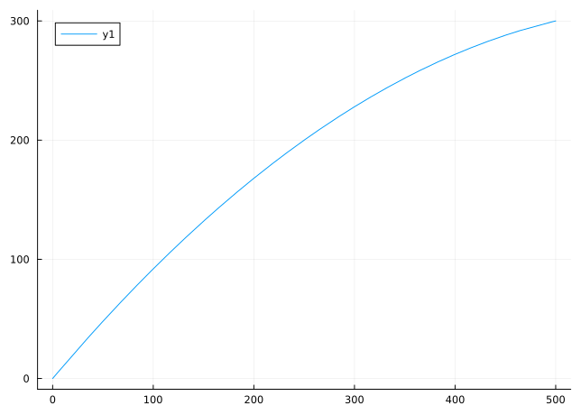

```julia
plot(j, 0, 500)
```

Well, we haven’t even seen the peak yet. Plotting over a wider interval will show that $1250$ is the largest root. So we plot over this domain to visualize the flight:

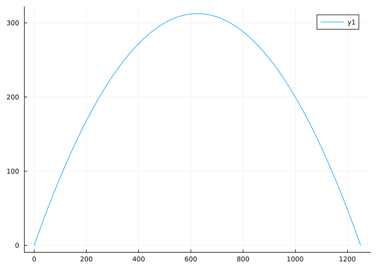

```julia
plot(j, 0, 1250)
```

As for the model with wind resistance, a quick plot over the same interval, $[0, 1250]$ yields:

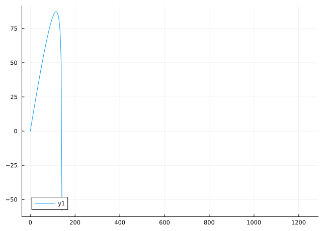

```julia
plot(y, 0, 1250)
```

The doesn’t show any values past $150$ or so. What happens if we try to evaluate at $1250$?

```julia
y(1250)
```

```
DomainError with -7.8388347648318435:
log was called with a negative real argument but will only return a complex result if called with a complex argument. Try log(Complex(x)).
Stacktrace:
 [1] throw_complex_domainerror(f::Symbol, x::Float64)
   @ Base.Math ./math.jl:33
 [2] _log
   @ ./special/log.jl:295 [inlined]
 [3] log(x::Float64)
   @ Base.Math ./special/log.jl:261
 [4] y(x::Int64; theta::Float64, g::Int64, v0::Int64, gamma::Int64)
   @ Main.Notebook ~/work/mth229.github.io/mth229.github.io/quarto/zeros.qmd:152
 [5] y(x::Int64)
   @ Main.Notebook ~/work/mth229.github.io/mth229.github.io/quarto/zeros.qmd:150
 [6] top-level scope
   @ ~/work/mth229.github.io/mth229.github.io/quarto/zeros.qmd:186
```

Oh, “Domain Error.” Of course, when the argument to the logarithm is negative we will have issues.

We solve for when $a-\gamma^2 x$ is $0$:

```julia
gamma = 1
a = 200 * cos(pi/4)
b = a/gamma^2
```

```
141.4213562373095
```

Anything bigger than this value, and we will get errors. We try graphing on the reduced interval avoiding the obvious *asymptote* at `b` by subtracting $1$:

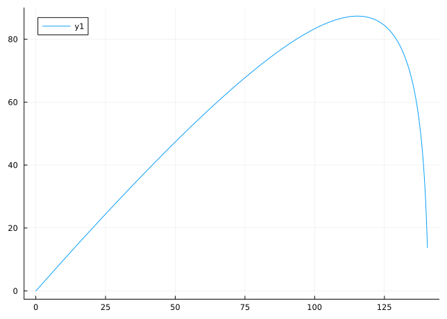

```julia
plot(y, 0, b - 1)
```

Now we can see the zero is around 140. We re-plot:

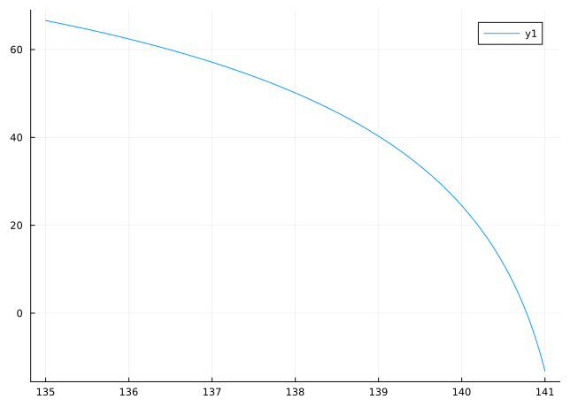

```julia
plot(y, 135, 141)
```

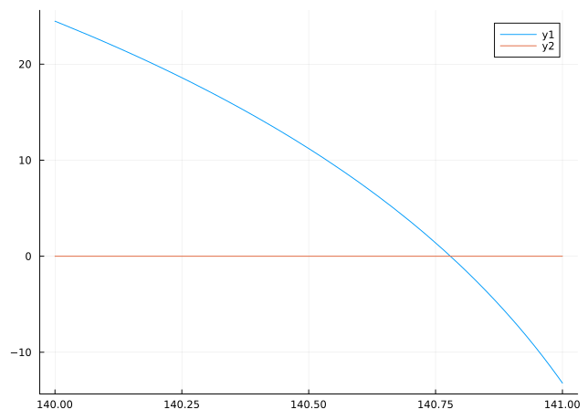

```julia
plot(y, 140, 141)
plot!(zero)
```

The answer is approximately $140.75$

Finally, we plot both graphs at once to see that it was a very windy day indeed.

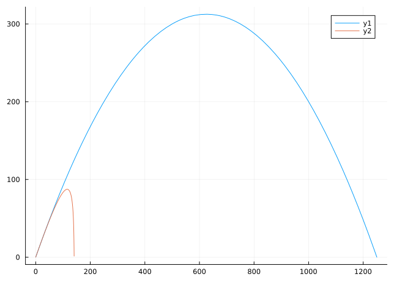

```julia
b = 140.75
plot(j , 0, 1250)
plot!(y, 0, b)
```

##### Example: Finding a zero

Sometimes, the equation $f(x)=0$ is actually presented as $f(x)= g(x)$. This form can be rewritten as $aux(x) = f(x) - g(x) = 0$, or if working graphically we can just look for crossing points of the graphs of $f(x)$ and $g(x)$. Here we shall do that.

We wish to compare two trash collection plans

- Plan 1: You pay 47.49 plus 0.77 per bag.
- Plan 2: You pay 30.00 plus 2.00 per bag.

There are some cases where plan 1 is cheaper and some where plan 2 is. Categorize them.

Both plans are *linear models* and may be expressed in *slope-intercept* form:

```julia
plan1(x) = 47.49 + 0.77x
plan2(x) = 30.00 + 2.00x
```

```
plan2 (generic function with 1 method)
```

Assuming this is a realistic problem and an average American household might produce 10-20 bags of trash a month (yes, that seems too much!) we plot in that range:

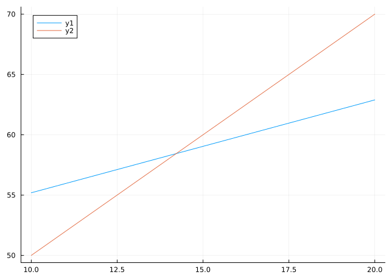

```julia
plot(plan1, 10, 20)
plot!(plan2)
```

We can see the intersection point is around 14 and that if a family generates between 0-14 bags of trash per month that plan 2 would be cheaper, otherwise they should opt for plan 1.

### 4.3.1 Practice

#### Question

Graphically estimate the one zero of $f(x) = e^x - x^3$ in the interval $[0,4]$.

#### Question

Solving equations of the type $f(x)=g(x)$ for $x$ can also be done graphically. One method is to plot *both* functions and look for crossing points. Use this approach to graphically estimate all solutions to $\cos(x) = x^2$ over the interval $(-\pi/2, \pi/2)$. What are they?

-1.57, 1.57

-0.82, 0.82

0.0

#### Question

In an analysis of rainbows, [Airy](http://en.wikipedia.org/wiki/Airy_function) developed a special function implemented as `airyai` in `Julia`’s `SpecialFunctions` package, which is loaded with the `MTH229` package. The zeros of this function are all negative. The first one is between $-3$ and $-1$. Find it graphically.

#### Question

The polynomial $f(x) = x^5 - 6x^3 - 6x^2 -7x - 6$ has three real roots. Which of the following values is not one of them? Try to solve this graphically.

5

3

-2

-1

#### Question

Let $y(x)$ be defined as above to model the flight of an arrow. If $\gamma=1/2$ when will the arrow strike the ground after launch?

#### Question

Let $y(x)$ be defined as above to model the flight of an arrow. Suppose a hill is in the path of the arrow. The hill is given by this function:

```julia
hill(x) = x > 100 ? 2.0 * (x-100) : 0.0
```

```
hill (generic function with 1 method)
```

By solving `y(x) = hill(x)` solve for how far the arrow will fly before hitting the hill.

## 4.4 Bisection algorithm

The last example had us graphically “zoom” in on a zero, and led us to an estimate to $1$ or $2$ decimal points. Trying to get more accuracy than that graphically is at best tedious. Here we discuss a method to get as much accuracy as is numerically possible based on the [intermediate value theorem](http://en.wikipedia.org/wiki/Intermediate_value_theorem):

**The intermediate value theorem**: If $f(x)$ is a continuous function on $[a,b]$ then at some point in the interval $f(x)$ takes on any value between $f(a)$ and $f(b)$.

In particular if $f(x)$ is continuous with $f(a)$ and $f(b)$ having *different* signs then there must be a point $c$ in $[a,b]$ where $f(c) = 0$. (When $f(a)$ and $f(b)$ have different signs, we say $a$ and $b$ *bracket* a root.) This observation is due to Bolzano.

The bisection algorithm finds a zero *between* two bracketing values, as illustrated in this graphic:

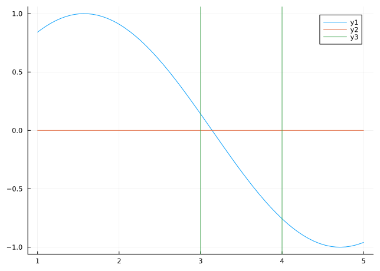

```julia
plot(sin, 1, 5)
plot!(zero)
vline!([3,4])
```

The zero of the sine function at $\pi$ is clearly *between* $3$ and $4$. The bisection algorithm is a method to refine the bracketing interval so that it is as small as possible.

The bisection algorithm utilizes Bolzano’s observation. It is a simple *iterative* procedure for finding such a value $c$ when we have a continuous function and a bracketing interval.

**NoteAlert**

The bisection method does not work when the function does not **cross** the $x$ axis at the root. For example, the zero at $0$ of $f(x) = x^2 e^x$ would not be found with this method. This is why a *bracketing* interval is needed to start the algorithm.

Mathematically the basic idea is simple.

Starting with $[a,b]$, the midpoint $M = (a + b)/2$, is tested for its function value. If $f(M) = 0$, great, we are done. If it has opposite sign of $f(a)$, then a root must be in the interval $[a,M]$, so the problem is reduced a smaller interval. Otherwise, it has opposite sign of $f(b)$ and the problem is reduced to $[M,b]$. Either way, the algorithm is repeated for the smaller interval where a root is known. As each step halves the interval length, it must eventually converge to an answer.

Graphically, we could do this. For example, Let’s consider $f(x) = x^2 - 2$ with the bracketing interval $[1,2]$. We first plot:

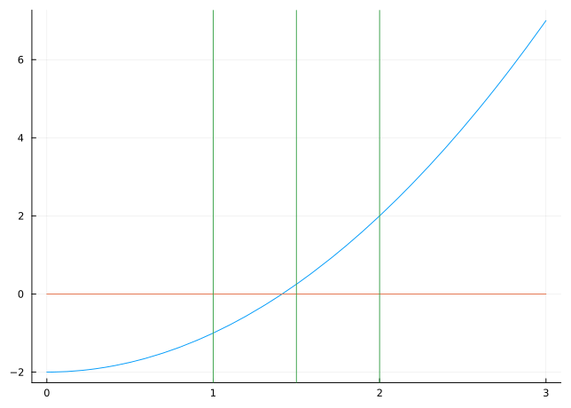

```julia
f(x) = x^2 - 2
a,b = 1, 2
plot(f, 0, 3; legend=false)
plot!(zero)
vline!([a, (a+b)/2, b])  # add vertical lines at a, b and midway
```

We can see that $c = (a + b)/2 = 3/2$ will have $f(c) > 0$, so the new bracket is $[a,c]$:

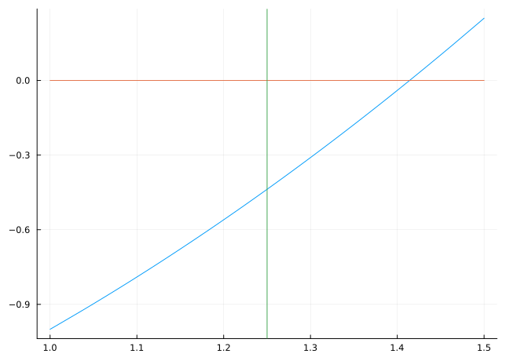

```julia
a, b = a, (a + b)/2

plot(f, a, b; legend=false)
plot!(zero)
vline!([(a+b)/2])
```

Now the function value at the midpoint is negative, so we modify `a`:

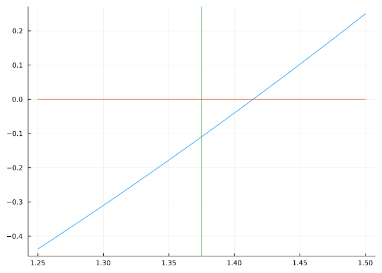

```julia
a, b = (a + b)/2, b

plot(f, a, b; legend=false)
plot!(zero)
vline!([(a+b)/2])
```

And again, this has a function value at the midpoint in the negative territory so again we modify `a`:

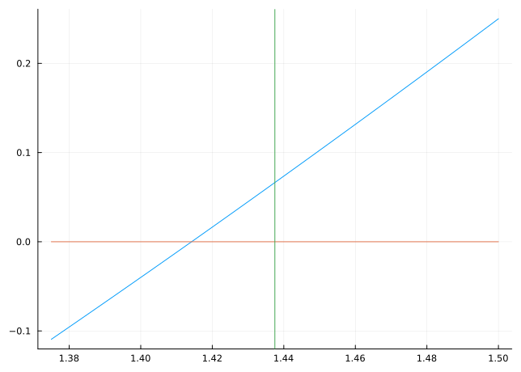

```julia
a, b = (a + b)/2, b

plot(f, a, b; legend=false)
plot!(zero)
vline!([(a+b)/2])
```

And now, as the midpoint is in positive territory we would modify $b$ …

This gets tedious to do graphically. But it can be easily programmed. The main step might look something like this:

```julia
f(x) = x^2 - 2
a, b = 1, 2

c = (a + b) /2

if f(a) * f(c) < 0
  a, b = a, c
else
  a, b = c, b
end
a, b
```

```
(1, 1.5)
```

Though some check if `f(c) == 0` is also needed.

Here $c=1.5$ and the new interval is $[1.0, 1.5]$, as we had graphically. We just need to repeat the above.

It seems as though we could be here all day. Indeed, if doing this by hand it might take up quite a bit of time. We should automate this. Before automating this, we need to think: *when would we stop?*

Mathematically we can keep taking halves using the concept of a limit. See for example [Zeno’s paradox](http://en.wikipedia.org/wiki/Zenos_paradoxes). On a computer we don’t have such a luxury. In fact, for floating point numbers we couldn’t keep taking halves—even if we wanted—as ultimately we should expect to get `a` and `b` being floating point values that are next to each other – and hence there is no midpoint. (Well, there are some cases that suggest a more careful numeric approach to the above.)

So even though this doesn’t make mathematical sense we can try stopping when the following condition is no longer true:

```julia
a < c < b
```

```
false
```

A `while` loop is used to repeat the central step until the above (or some variant) is `false`.

The `MTH229` package has a `bisection` method implemented for this which also outputs a graphical indication of the first few steps taken.

Okay, let’s look at the function $f(x) = -16x^2 + 32x$. We know that $0$ and $2$ are roots. Let’s see if our algorithm finds them:

```julia
f(x) = -16x^2 + 32x
bisection(f, -1, 1) ## should find 0
```

```
a###############################################################b
... exact answer found ...
```

```
0.0
```

```julia
bisection(f, 1, 3)  ## should find 2
```

```
a###############################################################b
... exact answer found ...
```

```
2.0
```

Okay, it seems to work. Lets try it on a less trivial problem. We know $\sin(x)$ and $\cos(x)$ cross in the interval $[0, \pi/2]$. If we are too tired to remember where, we can simply ask:

```julia
f(x) = cos(x) - sin(x)
x = bisection(f, 0, pi/2)
```

```
a###############################################################b
................................a###############################b
................................a###############b................
................................a#######b........................
................................a###b............................
................................a#b..............................
................................ab...............................
                                ⋮⋮
```

```
0.7853981633974483
```

Is `x` really a zero?

```julia
x, f(x)
```

```
(0.7853981633974483, 1.1102230246251565e-16)
```

Hmm, the answer is `1.1102230246251565e-16`. So technically this is not a zero. But *computationally* it is a zero! First it should be clear that it is *really close* to zero. We will see it is as close as computationally possible to a zero.

The `nextfloat` and `prevfloat` functions find the floating point values just bigger than `x` and just smaller. In this case we have that `f(x)` and `f(nextfloat(x))` have different signs:

```julia
f(x),  f(nextfloat(x))
```

```
(1.1102230246251565e-16, -1.1102230246251565e-16)
```

So $f$ is crossing $0$ between the value we found, `x` and, the floating point value just a bit bigger. We can’t realistically expect to get any closer than that, as there are no machine numbers in between these two.

#### Question

Plot `airyai` over `[-3,3]`. Which of the following is a *bracketing* interval?

[-1, 0]

[0, 1]

[-2, -1]

[-3, -2]

[2, 3]

[1, 2]

#### Question

Let $f(x) = e^x - x^4$ which of these intervals is a *bracketing interval* for a zero of $f$?

[0, 1]

[3, 4]

[1, 2]

[2, 3]

[4, 5]

#### Question

Let $f(x) = 1/2 + \sin(3x) + \sin(7x)$. Which of these is a *bracketing interval*?

[0, 1]

[-1, 0]

[-2, -1]

## 4.5 The Roots package and fzero to solve $f(x) = 0$

For example, to find a zero of $f(x) = 2x \cdot \exp(-20) - 2 \cdot \exp(-20x) + 1$ in the *bracketing* interval $[0,1]$ we have:

```julia
f(x) = 2x * exp(-20) - 2 * exp(-20x) + 1
fzero(f, 0, 1)
```

```
0.03465735902085385
```

**Notefind_zero**

In the `Roots` package, `fzero` is an alias to the `find_zero` function. We use it hear to save typing and inertial. The `find_zero` function is actually an interface to various root-finding algorithms. The `find_zero` function uses a container to specify the bracketing interval, like `(a,b)`. The `fzero` function also supports that alternate form, though we use `fzero(f, a, b)`, as that is the same pattern as used by plotting.

The bracketing interval can also be specified as a tuple, as in `(0,1)` which can offer some convenience, but isn’t necessary for interactive usage.

### 4.5.1 From a graph to a more accurate numeric answers

One needs to know where to look in order to use the bisection method. The basic “one-two punch” is:

- graph the function to identify bracketing values for which the zero is *between* $a$ and $b$. These need not be very precise, indeed for some problems $a$ and $b$ can even be infinite.
- use the bisection method to find the zero to many decimal points.

Here we illustrate with the problem of finding all intersection points of $e^x = x^4$ over the interval $[0,10]$.

Recall, solving for $f(x) = g(x)$ is identical to the problem of solving $aux(x) = 0$, where we define $aux(x) = f(x) - g(x)$. So our problem is to find solutions to $e^x - x^4 = 0$.

A quick plot shows that the function has such a wide range that looking over the entire domain at once will be problematic:

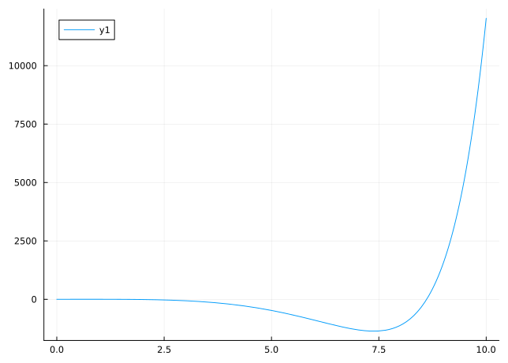

```julia
f(x) = exp(x) - x^4
plot(f, 0, 10)
```

The function is an exponential and a polynomial. A basic fact is that *eventually* exponentials grow *faster* so $f(x)$ will rapidly head towards $+\infty$, a fact that can be easily be observed bu plotting over a wider interval, such as $[0, 20]$. However, at $0$ we easily see that $f(x)$ is positive, it being $1-0$. So if the function dips negative, it must come back up, so we expect $2$ zeros. From the initial graph, it appears we can find them between $[0,7.5]$ and between $[7.5, 10]$.

So we find the values of the zero in the bracketed region $[7.5, 10]$:

```julia
fzero(f, (7.5, 10))
```

```
8.6131694564414
```

The root within $[0, 7.5]$ is found with:

```julia
fzero(f, (0, 7.5))
```

```
1.4296118247255556
```

We do this again. Find a zero of the function `f(x) = asinh(x) - e^2`.

As we don’t know much about this function, we first plot over $[-10,10}$:

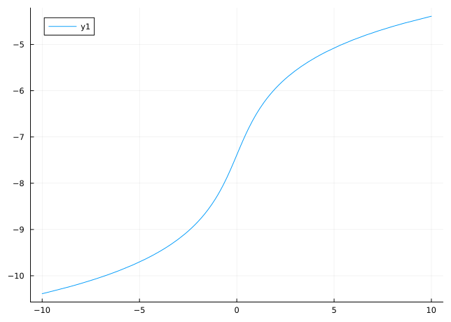

```julia
f(x) = asinh(x) - e^2
plot(f, -10, 10)
```

If we believe that the function is increasing, we can see then that any zero happens far to the right of $10$. Seeing this, we replot over $[0,1000]$:

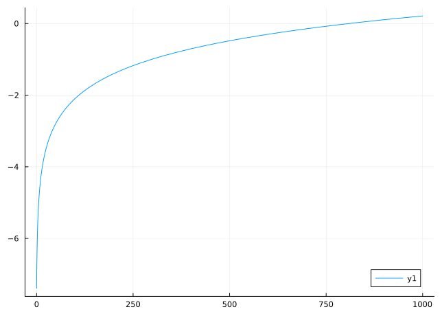

```julia
plot(f, 0, 1000)
```

From the graph, we confirm that $[0,1000]$ contains a zero and is a bracketing interval. With this, we are ready to call `fzero`:

```julia
fzero(f, 0, 1000)
```

```
809.0886869668318
```

### 4.5.2 Solving $f(x) = c$

There are two reasonable means to solve $f(x) = c$ for $x$ when $c$ is non-zero. As above, we can define a new function $aux(x) = f(x) - c$. Then when $aux(x)$ is $0$ we will have $f(x)$ equal to c.

Alternatively, we can pass in $c$ as a parameter by defining a two-argument version of $f.$

Suppose we aim to find when $\tan(x) = c$ for $c > 0$. For any $c > 0$, say $c = 1.23$, we can see from the shape of the graph of $\tan(x)$ that there is one intersection point between $0$ and $\pi/2$.

The easiest way is to create a simple function:

```julia
aux(x) = tan(x) - 1.23
fzero(aux, 0, pi/2)
```

```
0.8881737743776796
```

We can be more formal (as it is a more general pattern) and use two functions to define the problem:

```julia
f(x) = tan(x)
g(x) = 1.23
aux(x) = f(x) - g(x)
fzero(aux, 0, pi/2)
```

```
0.8881737743776796
```

We compare with the arc tangent, as there is a built-in function to do this particular problem:

```julia
atan(1.23)
```

```
0.8881737743776796
```

### 4.5.3 Solving $f(x) = g(x)$

The `fzero` function finds a value solving $f(x) = 0$. When the question involves two functions, e.g. $f(x) = g(x)$ it can’t be immediately used. However, forming an auxiliary function $aux(x) = f(x) - g(x)$ works as solutions to $aux(x) = 0$ satisfy $f(x) = g(x)$.

For example, identifying when $\cos(x) = 2x$ may be of interest. By simple geometry, the line through zero with positive slope will intersect the cosine graph somewhere in $[0, \pi/2]$:

We find where with the following approach:

```julia
f(x) = cos(x)
g(x) = 2x
aux(x) = f(x) - g(x)

fzero(aux, 0, pi/2)
```

```
0.45018361129487355
```

#### Example

The `secant(f, a, b)` function returns a *function* representing the secant line between $(a, f(a))$ and $(b, f(b))$. In the following we see where the secant line between $1$ and $2$ intersects that between $-2$ and $-1$ for $f(x) = e^x$.

Graphically, we have

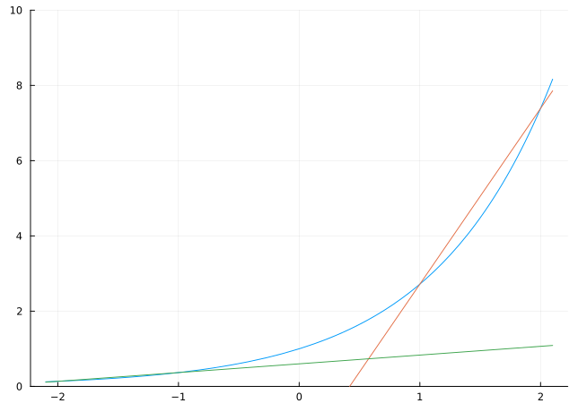

```julia
f(x) = exp(x)
plot(f, -2.1, 2.1; legend=false, ylims=(0, 10))
plot!(secant(f, 1, 2))
plot!(secant(f, -2, -1))
```

The intersection point near $0.5$ is clear. In the following we show how an infinite bracketing interval is possible. As two non-parallel lines intersect in one point, any open interval containing the intersection point will be a bracketing interval. The bisection algorithm of `fzero` handles without fuss any signed value, even infinite ones (though does stop if it encounters a `NaN` value).

```julia
f(x) = exp(x)
sl_12 = secant(f, 1, 2)
sl_21 = secant(f, -2, -1)
aux(x) = sl_12(x) - sl_21(x)
fzero(aux, -Inf, Inf)
```

```
0.5752103826044416
```

The above follows the pattern of using `aux(x)= f(x) - g(x)` to solve $f(x) = g(x)$. The intermediate names, `sl12` and `sl21`, are used for the two function here that we are finding the intersection of.

### 4.5.4 Using an equation to solve $f(x) = g(x)$

Symbolic math is touched on in section 5 using the powerful `SymPy` package. In anticipation we mention an alternate way to solve an equation $f(x) = g(x)$ using a symbolic variable.

The `MTH229` package loads the `SimpleExpressions` package which provides a means to create a basic symbolic variable (and parameter) through the macro `@symbolic`. `SymPy` will uses the more powerful `@syms` macro for a related task.

With a symbolic variable, computed expressions stay symbolic until needed. Symbolic expressions can be paired together with a `~` to create a *symbolic equation*. Such equations can be `solve`ed with the `solve` function. While `SymPy` can solve symbolic equations for algebraic answers, `SimpleExpressions` uses `fzero` behind the scenes.

So to solve when $\cos(x) = 2x$ we might have:

```julia
@symbolic x  # make a symbolic variable
eq = cos(x) ~ 2x
fzero(eq, 0, pi/2)
```

```
0.45018361129487355
```

(In the above, `cos(x)` and `2x` are examples of symbolic expressions.)

To solve an equation like $f(x) = c$, $c$ possibly zero is straightforward. For example we might have something like this:

```julia
f(x) = x * tanh(exp(x))
c = 1/2
fzero(f(x) ~ c, -5, 5)
```

```
0.5341051912972407
```

(In the above, applying `f(x)` to the symbolic `x` leaves a symbolic expression.)

To solve an equation like $f(x) = g(x)$, when two secant lines intersect, we have:

```julia
f(x) = exp(x)
sl_12 = secant(f, 1, 2)
sl_21 = secant(f, -2, -1)
fzero(sl_12(x) ~ sl_21(x), -Inf, Inf)
```

```
0.5752103826044416
```

For such symbolic equations, the `plot` function plots both the left and right hand sides, so we could visualize the above with:

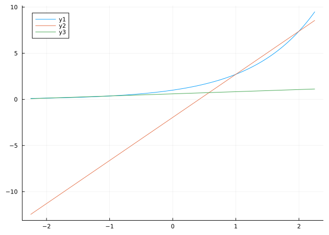

```julia
plot(f, -2.25, 2.25)
plot!(sl_12(x) ~ sl_21(x))
```

### 4.5.5 Problems

#### Question

In the bisection method algorithm we checked that the value of $f$ at $a$ and $b$ had opposite signs by looking at $f(a)\cdot f(b)$. Why did this work?

The product of two numbers is never negative

The product of two numbers will have the sign of the first one.

The product of 2 numbers with opposite signs is negative, the product of 2 numbers with the same signs is positive

#### Question: are there other roots in $[-10, 0]$?

There is another root in the interval $[-10, 0]$ for the function $f(x) = e^x - x^4$. Find its value numerically:

#### Question: relation between $x^2$ and $x \log(x)$

Let $f(x) = x^2 - 10 \cdot x \cdot \log(x)$. This function has two zeros on the positive $x$ axis. You are asked to find the largest (graph and bracket…):

#### Question

The `airyai` function has infinitely many negative roots, as the function oscillates when $x < 0$. In a previous problem we graphically found the largest root. Now find the *second largest root* using the graph to bracket the answer, and then solving.

#### Question: what goes up must come down…

[figure not shown]

Up and down

In 1638, according to Amir D. Aczel, an experiment was performed in the French Countryside. A monk, Marin Mersenne, launched a cannonball straight up into the air in an attempt to help Descartes prove facts about the rotation of the earth. Though the experiment was not successful, Mersenne later observed that the time for the cannonball to go up was greater than the time to come down. [According to “Vertical Projection in a Resisting Medium: Reflections on Observations of Mersenne”.](http://www.maa.org/publications/periodicals/american-mathematical-monthly/american-mathematical-monthly-contents-junejuly-2014)

This isn’t the case for simple ballistic motion where the time to go up is equal to the time to come down. We can “prove” this numerically. For simple ballistic motion, $f(t) = -(1/2)\cdot 32 t^2 + v_0t$. The time to go up and down are found by the two zeros of this function. The peak time is related to a zero of a function given by `D(f)`, which for now we’ll take as a mystery function, but later will be known as the derivative.

Let $v_0= 390$. The three times in question can be found from the zeros of `f` and `f'`. What are they?

\((0.0, 12.1875, 24.375)\)

\((-4.9731, 0.0, 4.9731)\)

\((0.0, 625.0, 1250.0)\)

#### Question: what goes up must come down… (again)

For simple ballistic motion you find that the time to go up is the time to come down. For motion within a resistant medium, such as air, this isn’t the case. Suppose a model for the height as a function of time is given by

$$h(t) = (\frac{g}{\gamma^2} + \frac{v_0}{\gamma})(1 - e^{-\gamma t}) - \frac{gt}{\gamma}$$

([From “On the trajectories of projectiles depicted in early ballistic Woodcuts”](http://www.researchgate.net/publication/230963032_On_the_trajectories_of_projectiles_depicted_in_early_ballistic_woodcuts))

Here $g=32$, again we take $v_0=390$, and $\gamma$ is a drag coefficient that we will take to be $1$. This is valid when $h(t) \geq 0$. In `Julia`, rather than hard-code the parameter values, for added flexibility we can pass them in as keyword arguments:

```julia
h(t; g=32, v0=390, gamma=1) = (g/gamma^2 + v0/gamma)*(1 - exp(-gamma*t)) - g*t/gamma
```

```
h (generic function with 1 method)
```

Now find the three times: $t_0$, the starting time; $t_a$, the time at the apex of the flight; and $t_f$, the time the object returns to the ground.

\((0, 2.579, 13.187)\)

\((0, 32.0, 390.0)\)

\((0, 13.187, 30.0)\)

## 4.6 Polynomials of higher degrees

For Polynomials of higher degree, there are some specific methods that can be used to identify the roots. We will demonstrate the methods from the `SymPy` package. These work on symbolic expressions. These will be described in more detail later, but for now, we have to make a *symbolic* variable, `x` to proceed:

```julia
@syms x
```

```
(x,)
```

The two functions we discuss are `sympy.roots` and `sympy.real_roots`.

First consider the quadratic equation below. We can identify the real roots of algebraic type with:

```julia
f(x) = x^2 + x - 1
sympy.real_roots(f(x))
```

$\left[\begin{smallmatrix}- \frac{\sqrt{5}}{2} - \frac{1}{2}\\- \frac{1}{2} + \frac{\sqrt{5}}{2}\end{smallmatrix}\right]$

That was so easy, we’ll do it again. What are the roots of the polynomial $f(x) = -16x^2 + 32x + 6$?

```julia
f(x) = -16x^2 + 32x + 6
sympy.real_roots(f(x))
```

$\left[\begin{smallmatrix}1 - \frac{\sqrt{22}}{4}\\1 + \frac{\sqrt{22}}{4}\end{smallmatrix}\right]$

As can be seen, $f$ has two real roots. This next polynomial has none:

```julia
f(x) = x^2 + x + 1
sympy.real_roots(f(x))
```

```
Any[]
```

### 4.6.1 All algebraic roots

These are examples of the general template **action(function_object, args…)** for performing some action on a function. In this case, the action is to find the roots of a function which specifies a polynomial function and the additional *args…* are not necessary–if only complex values are desired.

For some problems only the possible real roots are desired.

The following polynomial has both real roots and complex roots. The real one are

```julia
f(x) = (x^2 + x + 1) * (x^2 + x - 1)
sympy.real_roots(f(x))
```

$\left[\begin{smallmatrix}- \frac{\sqrt{5}}{2} - \frac{1}{2}\\- \frac{1}{2} + \frac{\sqrt{5}}{2}\end{smallmatrix}\right]$

Compare to

```julia
sympy.roots(f(x))
```

$$\begin{equation*}\begin{cases}- \frac{1}{2} + \frac{\sqrt{5}}{2} & \text{=>} &1\\- \frac{1}{2} + \frac{\sqrt{3} i}{2} & \text{=>} &1\\- \frac{1}{2} - \frac{\sqrt{3} i}{2} & \text{=>} &1\\- \frac{\sqrt{5}}{2} - \frac{1}{2} & \text{=>} &1\\\end{cases}\end{equation*}$$

The word “algebraic” was used, as some problems have answers, but not readily expressible ones. For example, `x^5 -x - 1`:

```julia
f(x) = x^5 - x - 1
sympy.roots(f(x))
```

```
Dict{Any, Any}()
```

However, the `solve` function (which solves `f(x)=0`) does hint at answers:

```julia
solve(f(x))
```

$\left[\begin{smallmatrix}\operatorname{CRootOf} {\left(x^{5} - x - 1, 0\right)}\\\operatorname{CRootOf} {\left(x^{5} - x - 1, 1\right)}\\\operatorname{CRootOf} {\left(x^{5} - x - 1, 2\right)}\\\operatorname{CRootOf} {\left(x^{5} - x - 1, 3\right)}\\\operatorname{CRootOf} {\left(x^{5} - x - 1, 4\right)}\end{smallmatrix}\right]$

These can be revealed, but converting them to numeric with `N`:

```julia
N.(solve(f(x)))
```

```
5-element Vector{Number}:
                     1.1673039782614187
 -0.7648844336005847 - 0.35247154603172626im
 -0.7648844336005847 + 0.35247154603172626im
 0.18123244446987538 - 1.0839541013177107im
 0.18123244446987538 + 1.0839541013177107im
```

### 4.6.2 Practice

#### Question

Find all roots of the function $f(x) = x^4 - 4x^2 -4x + 2$. Are they all real numbers?

No, none are real

No, some are real, some are complex

Yes, the are all real

#### Question

Find the largest real root of the polynomial $x^2 + x - 5$

#### Question

Find the largest real root of the polynomial $x^3 - x - 17$

#### Question

[The rule of signs of Descartes](http://en.wikipedia.org/wiki/Descartes_rule_of_signs) is a simple means to give an upper bound on the number of positive real roots a polynomial has. One counts the number of sign changes amongst the polynomials coefficients. Suppose this is $k$, then the number of *positive* real roots (counting multiplicities) is one of $k$, $k-2$, $k-4$, … . In particular if $k$ is odd, there must be at least one real root.

For example, the polynomial $x^3 -x^2 -x - 1$ has signs `+ - - -`, so there is just one sign change. This implies there must be exactly one *positive* real root, which is identifyied with:

```julia
f(x) = x^3 -x^2 -x - 1
N.(sympy.real_roots(f(x)))
```

```
1-element Vector{Float64}:
 1.8392867552141612
```

For the polynomial $f(x) = x^5 -x + 1$ has potentially 2 *positive*, real roots? Are there $0$ or $2$ positive, real roots?

two

zero

#### Question

The number of possible *negative*, real roots can also be found from Descartes’ rule. Instead of looking at the sign changes of $f(x)$, one must look at the sign changes of $g(x) = f(-x)$.

If $f(x) = x^5 - x +1$ we have $g(x) = -x^5 +x + 1$ (just change the signs of the coefficients of the odd powers). Then $g(x)$ has one sign change. This means there is one *negative* real root. What is it?

**NoteEnvironment of `Julia` when generated**

`Julia` version:

```
VERSION
```

```
v"1.12.6"
```

Packages and versions:

```
using Pkg
Pkg.status()
```

```
Status `~/work/mth229.github.io/mth229.github.io/Project.toml`
  [a2e0e22d] CalculusWithJulia v0.3.2
  [7073ff75] IJulia v1.34.4
  [b964fa9f] LaTeXStrings v1.4.0
  [ebaf19f5] MTH229 v0.3.2
  [91a5bcdd] Plots v1.41.6
  [f27b6e38] Polynomials v4.1.1
  [438e738f] PyCall v1.96.4
  [612c44de] QuizQuestions v0.3.27
  [295af30f] Revise v3.14.2
⌅ [f2b01f46] Roots v2.3.0
  [24249f21] SymPy v2.3.3
  [56ddb016] Logging v1.11.0
Info Packages marked with ⌅ have new versions available but compatibility constraints restrict them from upgrading. To see why use `status --outdated`
```